# Homework 3 - Null Distributions

Engineering Statistics I (MA223)

## Problem 1 (Clothing Store)

Retailers are becoming more adept at leveraging customer data to make decisions regarding the furture of the business. Customer loyalty cards, credit card purchases, and rewards programs provide incentives for customers to provide a corporation with information regarding their preferences and shopping behavior. An undisclosed store has provided data on a sample of 5000 individual customers and their behavior over the past year. The data, and a description of the variables available, is available on the course site (`CosthingStore`).

If you upload the data to RStudio in the same directory as this homework file, the following code will read in the dataset and name it clothes. **Note:** Many of the variables in this dataset have spaces; therefore, it is important that those variable names be surrounded in backticks when used in the code. See the FAQs in the Coding Cookbook for an example.

```r
clothes <- read_csv("ClothingStore.csv")
```

### Part (a)

The assistant manager would like to determine if the proportion of customers who have purchased a blouse in the past year exceeds 50%. State the parameter of interest, and then the null and alternative hypotheses that capture this question of interest.

### Part (b)

Construct a graphic which would help the assistant manager address her question of interest.

### Part (c)

Below are two graphics. One of the graphics represents a model for the sampling distribution of the statistic which estimate the parameter of interest. The other graphic represents a model for the null distribution of the statistic which estimates the parameter of interest.

Which graphic represents the *null distribution*? Explain.

Note: you need not understand the code; simply run it to construct the graphic.

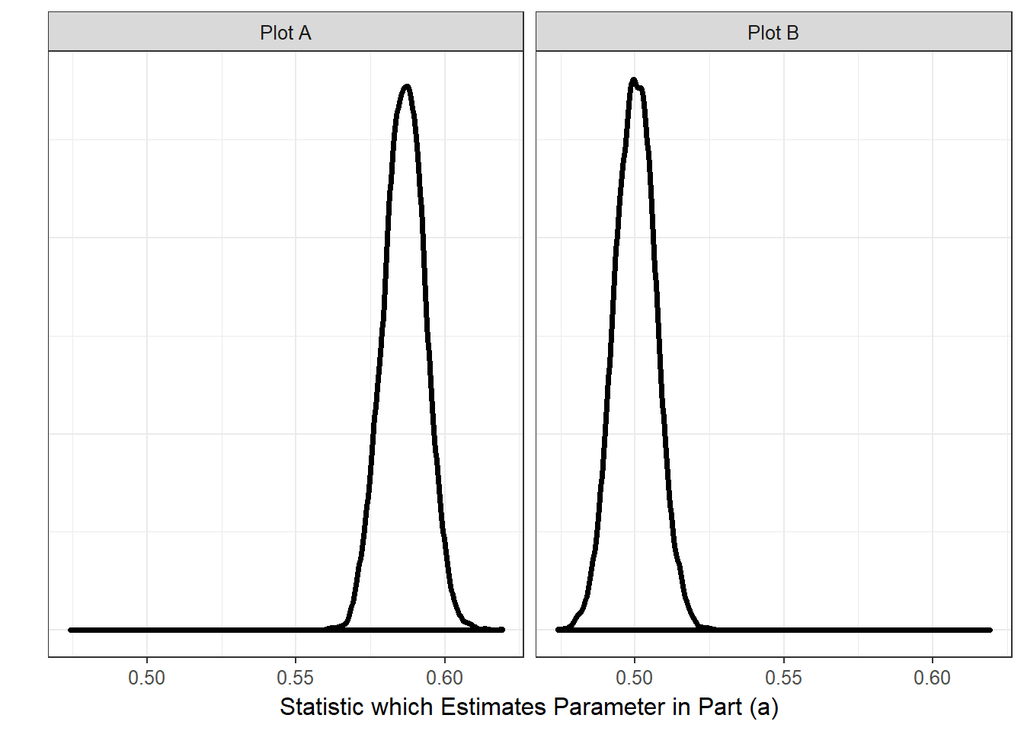

Models of the sampling and null distribution of the statistic of interest.

### Part (d)

Using the plot chosen in the part (c), which of the following values *most likely* represents the p-value?

1. $< 0.0001$
2. 0.01
3. 0.50
4. 0.99
5. $> 0.9999$

No justification required.

### Part (e)

Is there evidence that more than 50% of customers for this store purchased a blouse in the past year? Explain.

## Problem 2 (Clothing Store Cont.)

We will continue working with the data described in Problem 1 above. The district manager has set a goal for stores to average more than $475 in total sales per customer over the course of a year. If there is evidence stores meet this criteria, then the store manager will receive a bonus.

## Part (a)

The store manager would like to establish there is evidence that her store has met the district manager’s goal during the past year. State the parameter of interest for this study and the null and alternative hypotheses which capture this question of interest.

## Part (b)

Construct a graphic summarizing the distribution of total sales for customers in our sample which would help the store manager answer her question.

## Part (c)

On average, how much (total sales) did customers spend in the past year?

### Part (d)

Below is a figure representing the *null distribution* of the sample mean of total sales for 5000 customers over the past year. Which of the following values *most likely* represents the p-value corresponding to the hypotheses in part (a)?

1. 0.01
2. 0.34
3. 0.50
4. 0.66

No explanation needed. Note: you need not understand this code; simply run it (it will take a minute or two to run).

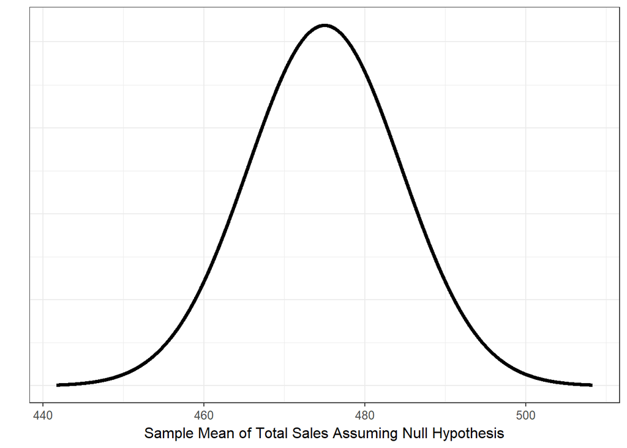

Model of the null distribution of the sample mean of total sales for 5000 customers. Model is based on 5000 bootstrap replications.

### Part (e)

The *district manager* believes this particular store has not demonstrated that the store manager deserves a bonus. Is his claim reasonable? Explain.